# ATAC-seq in Bioconductor exercises

Tom Carroll

In todays session we will work with some of the ATAC-seq data of T-regulatory cells from Christina Leslie’s lab.

Aligned data as a BAM file [can be found here.](https://www.encodeproject.org/files/ENCFF053CGD/@@download/ENCFF053CGD.bam)

The peak calls for ATAC-seq data [can be found here](https://www.encodeproject.org/files/ENCFF520GRD/@@download/ENCFF520GRD.bed.gz)

## ATAC-seq analysis.

1. Plot the nucleosome free abd mono-nucleosome signals over mouse genome mm10 TSS regions from the T-reg ATAC-seq data for chromosomes chr1 to chr19.

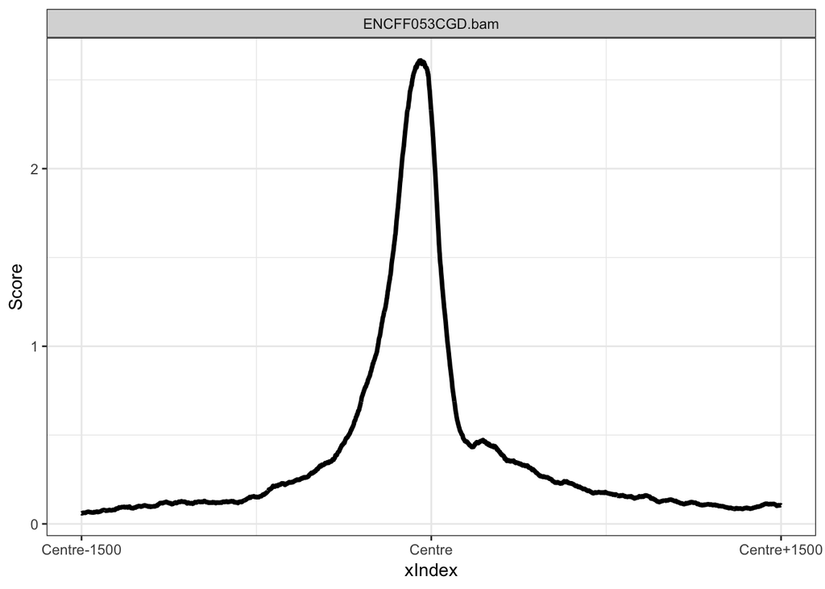

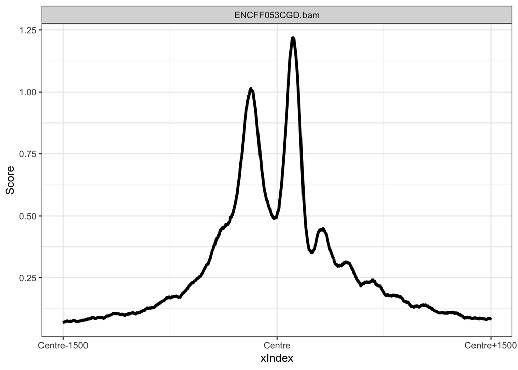

2. Extract the FRIP and Duplication rate for the Encode T-reg ATAC-seq BAM and associated peaks for chromosome 10.

```
## RiP%
## 43.9
```

```
## DuplicateByChIPQC
##          6.743219
```

3. For the Treg data produce a plot of transposase cut-sites for nucleosome free fragments around CTCF motifs on chromosome 18. Use the motif “Hsapiens-JASPAR_2014-CTCF-MA0139.1” from MotifDB package.

[output not shown]

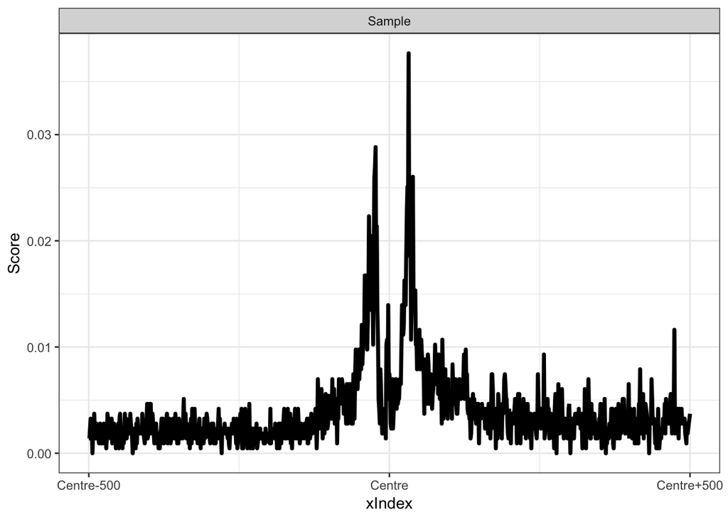

4. Load the counts for Encode Kidney, Liver and Hindbrain. Identify ATACseq sites significantly higher in Liver compared to Hindbrain (padj < 0.05 and padj is not NA) and perform a functional enrichment test using RGreat to identify BioCyc Pathways enriched in these sites.

Counts are in **../Data/myCounts.RData**

[output not shown]

```
## [1] "GO"                               "Phenotype Data and Human Disease"
## [3] "Pathway Data"                     "Gene Expression"
## [5] "Regulatory Motifs"                "Gene Families"
```

```
## [1] "PANTHER Pathway" "BioCyc Pathway"  "MSigDB Pathway"
```

```
##             ID
## 1     PWY-5920
## 2     PWY-5189
## 3 PWY3DJ-11470
## 4     PWY-6358
##                                                                     name
## 1                                                   heme biosynthesis II
## 2                                           tetrapyrrole biosynthesis II
## 3                     sphingosine and sphingosine-1-phosphate metabolism
## 4 superpathway of D-<i>myo</i>-inositol (1,4,5)-trisphosphate metabolism
##   Binom_Genome_Fraction Binom_Expected Binom_Observed_Region_Hits
## 1          2.378908e-04      2.3337090                         26
## 2          9.254901e-05      0.9079058                         14
## 3          5.385445e-04      5.2831220                         26
## 4          4.999543e-04      4.9045520                         23
```

[output cut: 20 more lines]